# Introduction to the benthos-package

Dennis Walvoort

2022-08-22

## Introduction

The `benthos`-package provides functions for analysing benthic data sets. To use the `benthos` package, some basic knowledge of programming in R (R Core Team, 2017; www.r-project.org) is assumed.

The functions in the `benthos`-package have been designed to integrate seamlessly with those of the `dplyr`-package (Wickham *et al.*, 2017). The `dplyr`-package implements a grammar of data manipulation to make data analysis more efficient and clear.

The `benthos`-package is designed to use the forward-pipe operator (`%>%`) provided by the `magrittr`-package (Milton Bache & Wickham, 2014). This operator can be used for chaining multiple data operations together. This reduces the need for temporary variables or nested function calls and leads to cleaner and more readable code. Consult the references below and the corresponding package vignettes for more information.

The `benthos`-package follows the same philosophy as the `dplyr` package: in stead of providing complicated functions that can do many tasks (‘Swiss army knife’-functions), we provide a set of *‘small functions that each do one thing well’* (Wickham & Francois, 2017; ‘Introduction to `dplyr` vignette’). As a consequence, you will not find functions in this package which perform a complete analysis, rather it provides basic building blocks that you can use to build your own functions and applications.

## Loading the package

The `benthos`-package can be attached by means of

```r
library(benthos)
```

In this vignette, we also attach the `dplyr`, `tidyr`, `readr` and `ggplot2` packages for data manipulation and visualization.

```r
library(dplyr)
library(tidyr)
library(readr)
library(ggplot2)
```

## Sample data set

In the sections below, we will illustrate the `benthos`-package by means of the Oosterschelde marine benthos data set. This data set ships with the `benthos`-package and can be loaded by typing:

```r
data(oosterschelde)
```

The first 10 records of these data set are given below:

```r
oosterschelde
# A tibble: 4,269 × 8
   OBJECTID     SAMPLEID DATE          ID HABITAT               AREA TAXON                COUNT
   <chr>           <int> <date>     <int> <chr>                <dbl> <chr>                <int>
 1 nl89_oostsde    14956 2010-09-06     1 Polyhaline-Subtidal 0.0157 Aphelochaeta marioni     1
 2 nl89_oostsde    14956 2010-09-06     1 Polyhaline-Subtidal 0.0157 Crangon crangon          1
 3 nl89_oostsde    14956 2010-09-06     1 Polyhaline-Subtidal 0.0157 Nephtys hombergii        4
 4 nl89_oostsde    14956 2010-09-06     1 Polyhaline-Subtidal 0.0157 Oligochaeta              5
 5 nl89_oostsde    14956 2010-09-06     1 Polyhaline-Subtidal 0.0157 Pygospio elegans        12
 6 nl89_oostsde    14956 2010-09-06     1 Polyhaline-Subtidal 0.0157 Scoloplos armiger        1
 7 nl89_oostsde    14956 2010-09-06     1 Polyhaline-Subtidal 0.0157 Spio martinensis         1
 8 nl89_oostsde    14956 2010-09-06     1 Polyhaline-Subtidal 0.0157 Spiophanes bombyx        8
 9 nl89_oostsde    14957 2010-09-06     2 Polyhaline-Subtidal 0.0157 Corophium arenarium      1
10 nl89_oostsde    14957 2010-09-06     2 Polyhaline-Subtidal 0.0157 Nephtys cirrosa          1
# ℹ 4,259 more rows
```

Type

```r
?oosterschelde
```

to see the documentation of this data set.

## Preprocessing

Data preprocessing is an important first step. In this section we will demonstrate some preprocessing steps.

### Selecting variables and observations

As a simple preprocessing step, we will only consider samples (stored in rows) taken in August and September. These can be selected as follows:

```r
oosterschelde <- oosterschelde %>%
    filter(months(DATE) %in% c("August", "September"))
```

### Standardization of taxon names

Taxon names need to be standardized to comply with the names in the WoRMS-database. The `as_accepted`-function does this conversion by using the TWN-list (https://taxainfo.nl/). This list is based on the WoRMS database (World Register of Marine Species, https://www.marinespecies.org/).

We can use the `is_accepted`-function to check if a taxon complies with WoRMS:

```r
oosterschelde %>%
    mutate(COMPLIANT = is_accepted(taxon = TAXON)) %>%
    select(OBJECTID, HABITAT, DATE, TAXON, COUNT, COMPLIANT)
# A tibble: 3,737 × 6
   OBJECTID     HABITAT             DATE       TAXON                COUNT COMPLIANT
   <chr>        <chr>               <date>     <chr>                <int> <lgl>
 1 nl89_oostsde Polyhaline-Subtidal 2010-09-06 Aphelochaeta marioni     1 TRUE
 2 nl89_oostsde Polyhaline-Subtidal 2010-09-06 Crangon crangon          1 TRUE
 3 nl89_oostsde Polyhaline-Subtidal 2010-09-06 Nephtys hombergii        4 TRUE
 4 nl89_oostsde Polyhaline-Subtidal 2010-09-06 Oligochaeta              5 TRUE
 5 nl89_oostsde Polyhaline-Subtidal 2010-09-06 Pygospio elegans        12 TRUE
 6 nl89_oostsde Polyhaline-Subtidal 2010-09-06 Scoloplos armiger        1 TRUE
 7 nl89_oostsde Polyhaline-Subtidal 2010-09-06 Spio martinensis         1 TRUE
 8 nl89_oostsde Polyhaline-Subtidal 2010-09-06 Spiophanes bombyx        8 TRUE
 9 nl89_oostsde Polyhaline-Subtidal 2010-09-06 Corophium arenarium      1 TRUE
10 nl89_oostsde Polyhaline-Subtidal 2010-09-06 Nephtys cirrosa          1 TRUE
# ℹ 3,727 more rows
```

This returns a logical vector with `TRUE` if a taxon complies with WoRMS and `FALSE` otherwise. The total number of records, compliant names, and missing names is given below

```r
oosterschelde %>%
    mutate(COMPLIANT = is_accepted(taxon = TAXON)) %>%
    summarise(
        N_RECORDS = n(),
        N_COMPLIANT = sum(COMPLIANT),
        N_MISSING = N_RECORDS - N_COMPLIANT
    )
# A tibble: 1 × 3
  N_RECORDS N_COMPLIANT N_MISSING
      <int>       <int>     <int>
1      3737        3718        19
```

Taxa not compliant with WoRMS (if any) are given below and will be removed:

```r
oosterschelde %>%
    filter(!is_accepted(taxon = TAXON))
# A tibble: 19 × 8
   OBJECTID     SAMPLEID DATE          ID HABITAT                 AREA TAXON     COUNT
   <chr>           <int> <date>     <int> <chr>                  <dbl> <chr>     <int>
 1 nl89_oostsde    14964 2010-09-06     8 Polyhaline-Subtidal   0.0774 Crustacea     1
 2 nl89_oostsde    14972 2010-09-06    16 Polyhaline-Subtidal   0.0157 Insecta       1
 3 nl89_oostsde    14983 2010-09-07    17 Polyhaline-Subtidal   0.0157 Insecta       1
 4 nl89_oostsde    15005 2010-09-07    39 Polyhaline-Subtidal   0.0157 Crustacea     1
 5 nl89_oostsde    15025 2010-09-10    59 Polyhaline-Intertidal 0.0157 Insecta       3
 6 nl89_oostsde    15075 2010-09-24    73 Polyhaline-Intertidal 0.0157 Insecta       1
 7 nl89_oostsde    15468 2011-08-18   134 Polyhaline-Intertidal 0.0157 Animalia      1
 8 nl89_oostsde    15260 2011-09-08   199 Polyhaline-Subtidal   0.0157 Animalia      1
 9 nl89_oostsde    15507 2011-09-13   205 Polyhaline-Intertidal 0.0157 Animalia      1
10 nl89_oostsde    15241 2011-09-13   206 Polyhaline-Intertidal 0.0157 Animalia      1
11 nl89_oostsde    15509 2011-09-14   215 Polyhaline-Intertidal 0.0157 Animalia      1
12 nl89_oostsde    15631 2012-08-29   295 Polyhaline-Subtidal   0.0774 Animalia      1
13 nl89_oostsde    15633 2012-08-27   297 Polyhaline-Subtidal   0.0157 Crustacea     1
14 nl89_oostsde    15651 2012-08-29   315 Polyhaline-Subtidal   0.0157 Animalia      1
15 nl89_oostsde    15675 2012-08-27   339 Polyhaline-Subtidal   0.0157 Animalia      1
16 nl89_oostsde    15707 2012-09-18   369 Polyhaline-Intertidal 0.0157 Animalia      1
17 nl89_oostsde    15708 2012-09-06   370 Polyhaline-Intertidal 0.0157 Animalia      1
18 nl89_oostsde    15710 2012-08-20   372 Polyhaline-Intertidal 0.0157 Animalia      1
19 nl89_oostsde    15720 2012-08-20   382 Polyhaline-Intertidal 0.0157 Animalia      1
oosterschelde <- oosterschelde %>%
    filter(is_accepted(taxon = TAXON))
```

Other examples of the usage of the `is_accepted` and `as_accepted`-functions are:

```r
is_accepted(taxon = "Petricola pholadiformis")
[1] FALSE
as_accepted(taxon = "Petricola pholadiformis")
[1] "Petricolaria pholadiformis"
is_accepted(taxon = "Petricolaria pholadiformis")
[1] TRUE
```

If we want to make sure that all taxa names comply with WoRMS we simply use:

```r
oosterschelde <- oosterschelde %>%
    mutate(TAXON = as_accepted(TAXON))
```

Taxon names that are not in the WoRMS/TWN-list get name `NA` (not available):

```r
oosterschelde %>%
    filter(!is_accepted(taxon = TAXON)) %>%
    nrow
[1] 0
```

In our case all names comply with those in WoRMS.

### Genus to species conversion

Genus to species conversion reallocates the counts of taxa that are identified at the genus level to taxa in the same sampling unit and of the same genus but that are identified on the species level. The redistribution of counts is proportional to the number of counts of taxa at the species level (Van Loon *et al*., 2015).

The Oosterschelde data set only contains individuals at the genus and species level (individuals at higher order taxonomic levels have been removed for didactic purposes only).

It is convenient to split each taxon into its generic and specific name. This can be accomplished as follows:

```r
oosterschelde <- oosterschelde %>%
    mutate(
        GENERIC  = generic_name(TAXON),
        SPECIFIC = specific_name(TAXON)
    )
oosterschelde
# A tibble: 3,718 × 10
   OBJECTID     SAMPLEID DATE          ID HABITAT               AREA TAXON    COUNT GENERIC SPECIFIC
   <chr>           <int> <date>     <int> <chr>                <dbl> <chr>    <int> <chr>   <chr>
 1 nl89_oostsde    14956 2010-09-06     1 Polyhaline-Subtidal 0.0157 Apheloc…     1 Aphelo… marioni
 2 nl89_oostsde    14956 2010-09-06     1 Polyhaline-Subtidal 0.0157 Crangon…     1 Crangon crangon
 3 nl89_oostsde    14956 2010-09-06     1 Polyhaline-Subtidal 0.0157 Nephtys…     4 Nephtys homberg…
 4 nl89_oostsde    14956 2010-09-06     1 Polyhaline-Subtidal 0.0157 Oligoch…     5 <NA>    <NA>
 5 nl89_oostsde    14956 2010-09-06     1 Polyhaline-Subtidal 0.0157 Pygospi…    12 Pygosp… elegans
 6 nl89_oostsde    14956 2010-09-06     1 Polyhaline-Subtidal 0.0157 Scolopl…     1 Scolop… armiger
 7 nl89_oostsde    14956 2010-09-06     1 Polyhaline-Subtidal 0.0157 Spio ma…     1 Spio    martine…
 8 nl89_oostsde    14956 2010-09-06     1 Polyhaline-Subtidal 0.0157 Spiopha…     8 Spioph… bombyx
 9 nl89_oostsde    14957 2010-09-06     2 Polyhaline-Subtidal 0.0157 Corophi…     1 Coroph… arenari…
10 nl89_oostsde    14957 2010-09-06     2 Polyhaline-Subtidal 0.0157 Nephtys…     1 Nephtys cirrosa
# ℹ 3,708 more rows
```

Both functions `generic_name` and `specific_name` return `NA` if TAXON is not a valid binomial. That is the case if a taxon has only been identified on the genus level. For example:

```r
is_binomen("Nephtys")
[1] FALSE
is_binomen("Nephtys cirrosa")
[1] TRUE
```

We will create a new column to indicate these cases.

```r
oosterschelde <- oosterschelde %>%
    mutate(
        IS_GENUS = is.na(GENERIC),
        GENERIC = ifelse(IS_GENUS, TAXON, GENERIC)
    )
```

The number of taxa that has been identified at the genus level is

```r
oosterschelde %>%
    filter(IS_GENUS) %>%
    nrow
[1] 1426
```

Genus to species conversion is performed for each genus in a sample by means of the `genus_to_species` function:

```r
oosterschelde <- oosterschelde %>%
    group_by(ID, GENERIC) %>%
    mutate(NEWCOUNT = genus_to_species(is_genus = IS_GENUS, count = COUNT)) %>%
    ungroup
```

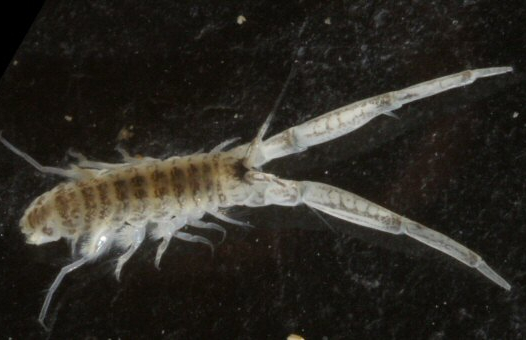

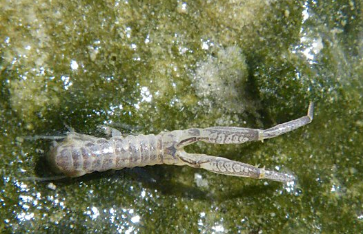

*Corophium arenarium* (left) and *Corophium volutator* (right) (source: https://nature22.com/)

To illustrate the algorithm, consider all records with generic name *Corophium* in sample 130:

```r
oosterschelde %>%
    filter(GENERIC == "Corophium", ID == 130) %>%
    arrange(TAXON)
# A tibble: 3 × 12
  OBJECTID   SAMPLEID DATE          ID HABITAT   AREA TAXON COUNT GENERIC SPECIFIC IS_GENUS NEWCOUNT
  <chr>         <int> <date>     <int> <chr>    <dbl> <chr> <int> <chr>   <chr>    <lgl>       <dbl>
1 nl89_oost…    15432 2011-08-18   130 Polyha… 0.0236 Coro…     5 Coroph… <NA>     TRUE         0
2 nl89_oost…    15432 2011-08-18   130 Polyha… 0.0236 Coro…    17 Coroph… arenari… FALSE       21.5
3 nl89_oost…    15432 2011-08-18   130 Polyha… 0.0236 Coro…     2 Coroph… volutat… FALSE        2.53
```

In this sample, the genus *Corophium* is identified 19 times at the species level, *i.e.*, 17 times as *Corophium arenarium* and twice as *Corophium volutator*. For five individuals, the analyst was unable to identify the species name, and only reported the genus. The genus to species algorithm now proportionally reallocates the $5$ individuals at the genus level to the taxa at the species level. That is, an additional $5 \times \frac{17}{17 + 2} = 4.47$ individuals will be classified as *Corophium arenarium* and $5 \times \frac{2}{17 + 2} = 0.53$ as *Corophium volutator*.

```r
oosterschelde %>%
    summarise(sum(COUNT), sum(NEWCOUNT))
# A tibble: 1 × 2
  `sum(COUNT)` `sum(NEWCOUNT)`
         <int>           <dbl>
1        33079           33079
```

To finalize our analysis, we will set COUNT to the value of NEWCOUNT, and remove redundant columns and records.

```r
oosterschelde <- oosterschelde %>%
    mutate(COUNT = NEWCOUNT) %>%
    select(ID, HABITAT, AREA, DATE, TAXON, COUNT) %>%
    filter(COUNT > 0)
oosterschelde
# A tibble: 3,562 × 6
      ID HABITAT               AREA DATE       TAXON                COUNT
   <int> <chr>                <dbl> <date>     <chr>                <dbl>
 1     1 Polyhaline-Subtidal 0.0157 2010-09-06 Aphelochaeta marioni     1
 2     1 Polyhaline-Subtidal 0.0157 2010-09-06 Crangon crangon          1
 3     1 Polyhaline-Subtidal 0.0157 2010-09-06 Nephtys hombergii        4
 4     1 Polyhaline-Subtidal 0.0157 2010-09-06 Oligochaeta              5
 5     1 Polyhaline-Subtidal 0.0157 2010-09-06 Pygospio elegans        12
 6     1 Polyhaline-Subtidal 0.0157 2010-09-06 Scoloplos armiger        1
 7     1 Polyhaline-Subtidal 0.0157 2010-09-06 Spio martinensis         1
 8     1 Polyhaline-Subtidal 0.0157 2010-09-06 Spiophanes bombyx        8
 9     2 Polyhaline-Subtidal 0.0157 2010-09-06 Corophium arenarium      1
10     2 Polyhaline-Subtidal 0.0157 2010-09-06 Nephtys cirrosa          1
# ℹ 3,552 more rows
```

### Data pooling

Analysis results make only sense when all sampling units are collected on the same support. That is not the case for the oosterschelde data:

```r
d <- oosterschelde %>%
    group_by(AREA) %>%
    summarise(n = n())
d
# A tibble: 3 × 2
    AREA     n
   <dbl> <int>
1 0.0157  3229
2 0.0236    81
3 0.0774   252
```

We distinguish three different supports (0.0157, 0.0236, 0.0774 m<sup>2</sup>). In this section, we will demonstrate how to pool these data to approximately the same support in the range from 0.09 to 0.11 m<sup>2</sup>. See Van Loon *et al.* (2015) for more details.

We will only pool samples of the same year, so we’ll start by adding a new column to our table containing the year:

```r
oosterschelde <- oosterschelde %>%
    mutate(YEAR = DATE %>% format("%Y"))
```

Next, we will randomly pool samples for each HABITAT and YEAR. We will pool several times (in the example below `n_pool_runs = 10`), to reduce the effect of pool composition and to make sure that each sample will be represented in a pool (no leftovers on average).

```r
n_pool_runs <- 10
pool_runs <- replicate(
    n = n_pool_runs, {
    oosterschelde %>%
        group_by(HABITAT, YEAR) %>%
        mutate(
            POOLID = pool(
                sample_id = ID,
                area = AREA,
                target_area = c(0.09, 0.11)
            )
        ) %>%
        ungroup %>%
        select(POOLID)
    }
)
```

This procedure will return al list of pool identifiers (POOLID) for each pool run:

```r
names(pool_runs) <- paste0("POOLRUN", 1:n_pool_runs)
pool_runs <- pool_runs %>% as_tibble
pool_runs
# A tibble: 3,562 × 10
   POOLRUN1 POOLRUN2 POOLRUN3 POOLRUN4 POOLRUN5 POOLRUN6 POOLRUN7 POOLRUN8 POOLRUN9 POOLRUN10
      <int>    <int>    <int>    <int>    <int>    <int>    <int>    <int>    <int>     <int>
 1        7       NA        3        1        2       NA       10       NA       NA        NA
 2        7       NA        3        1        2       NA       10       NA       NA        NA
 3        7       NA        3        1        2       NA       10       NA       NA        NA
 4        7       NA        3        1        2       NA       10       NA       NA        NA
 5        7       NA        3        1        2       NA       10       NA       NA        NA
 6        7       NA        3        1        2       NA       10       NA       NA        NA
 7        7       NA        3        1        2       NA       10       NA       NA        NA
 8        7       NA        3        1        2       NA       10       NA       NA        NA
 9        9        2        6        3        2        4        8        3        8        10
10        9        2        6        3        2        4        8        3        8        10
# ℹ 3,552 more rows
```

Each row in this table corresponds to the row with the same index in `oosterschelde`. Therefore, it is quite easy to combine this table with the ‘oosterschelde’ data:

```r
oosterschelde_orig <- oosterschelde
oosterschelde <- oosterschelde %>%
    bind_cols(pool_runs) %>%
    as_tibble
oosterschelde
# A tibble: 3,562 × 17
      ID HABITAT      AREA DATE       TAXON COUNT YEAR  POOLRUN1 POOLRUN2 POOLRUN3 POOLRUN4 POOLRUN5
   <int> <chr>       <dbl> <date>     <chr> <dbl> <chr>    <int>    <int>    <int>    <int>    <int>
 1     1 Polyhalin… 0.0157 2010-09-06 Aphe…     1 2010         7       NA        3        1        2
 2     1 Polyhalin… 0.0157 2010-09-06 Cran…     1 2010         7       NA        3        1        2
 3     1 Polyhalin… 0.0157 2010-09-06 Neph…     4 2010         7       NA        3        1        2
 4     1 Polyhalin… 0.0157 2010-09-06 Olig…     5 2010         7       NA        3        1        2
 5     1 Polyhalin… 0.0157 2010-09-06 Pygo…    12 2010         7       NA        3        1        2
 6     1 Polyhalin… 0.0157 2010-09-06 Scol…     1 2010         7       NA        3        1        2
 7     1 Polyhalin… 0.0157 2010-09-06 Spio…     1 2010         7       NA        3        1        2
 8     1 Polyhalin… 0.0157 2010-09-06 Spio…     8 2010         7       NA        3        1        2
 9     2 Polyhalin… 0.0157 2010-09-06 Coro…     1 2010         9        2        6        3        2
10     2 Polyhalin… 0.0157 2010-09-06 Neph…     1 2010         9        2        6        3        2
# ℹ 3,552 more rows
# ℹ 5 more variables: POOLRUN6 <int>, POOLRUN7 <int>, POOLRUN8 <int>, POOLRUN9 <int>,
#   POOLRUN10 <int>
```

It was not always possible to use all samples for pooling. These ‘leftover’ samples have POOLID `NA`. However, on average each sample has been pooled between 5 and 10 times.

For further analysis, it is convenient to convert this table from ‘wide’ to ‘long’-format. This can be done efficiently by functions of the `tidyr`-package (Wickham, 2017), which provides an interesting framework to tidy your data (Wickham, 2014).

```r
oosterschelde <- oosterschelde %>%
    gather(key = "POOLRUN", value = "POOLID", starts_with("POOLRUN")) %>%
    mutate(POOLRUN = parse_number(POOLRUN) %>% as.integer) %>%
    filter(!is.na(POOLID)) %>%
    select(POOLRUN, POOLID, HABITAT, AREA, YEAR, ID, TAXON, COUNT)
oosterschelde
# A tibble: 33,439 × 8
   POOLRUN POOLID HABITAT               AREA YEAR     ID TAXON                COUNT
     <int>  <int> <chr>                <dbl> <chr> <int> <chr>                <dbl>
 1       1      7 Polyhaline-Subtidal 0.0157 2010      1 Aphelochaeta marioni     1
 2       1      7 Polyhaline-Subtidal 0.0157 2010      1 Crangon crangon          1
 3       1      7 Polyhaline-Subtidal 0.0157 2010      1 Nephtys hombergii        4
 4       1      7 Polyhaline-Subtidal 0.0157 2010      1 Oligochaeta              5
 5       1      7 Polyhaline-Subtidal 0.0157 2010      1 Pygospio elegans        12
 6       1      7 Polyhaline-Subtidal 0.0157 2010      1 Scoloplos armiger        1
 7       1      7 Polyhaline-Subtidal 0.0157 2010      1 Spio martinensis         1
 8       1      7 Polyhaline-Subtidal 0.0157 2010      1 Spiophanes bombyx        8
 9       1      9 Polyhaline-Subtidal 0.0157 2010      2 Corophium arenarium      1
10       1      9 Polyhaline-Subtidal 0.0157 2010      2 Nephtys cirrosa          1
# ℹ 33,429 more rows
```

To check if the pooling algorithm succeeded in its task, we compute the area of each pool. These areas should vary between 0.09 and 0.11 m<sup>2</sup>, *i.e.*, our target area.

```r
d <- oosterschelde %>%
    group_by(HABITAT, YEAR, POOLRUN, POOLID) %>%
    select(ID, AREA) %>%
    distinct(ID, AREA) %>%
    summarise(AREA = sum(AREA))
Adding missing grouping variables: `HABITAT`, `YEAR`, `POOLRUN`, `POOLID`
`summarise()` has grouped output by 'HABITAT', 'YEAR', 'POOLRUN'. You can override using the
`.groups` argument.
d
# A tibble: 569 × 5
# Groups:   HABITAT, YEAR, POOLRUN [60]
   HABITAT               YEAR  POOLRUN POOLID   AREA
   <chr>                 <chr>   <int>  <int>  <dbl>
 1 Polyhaline-Intertidal 2010        1      1 0.0942
 2 Polyhaline-Intertidal 2010        1      2 0.0942
 3 Polyhaline-Intertidal 2010        1      3 0.0942
 4 Polyhaline-Intertidal 2010        1      4 0.0942
 5 Polyhaline-Intertidal 2010        1      5 0.0942
 6 Polyhaline-Intertidal 2010        1      6 0.0942
 7 Polyhaline-Intertidal 2010        1      7 0.0942
 8 Polyhaline-Intertidal 2010        2      1 0.0942
 9 Polyhaline-Intertidal 2010        2      2 0.0942
10 Polyhaline-Intertidal 2010        2      3 0.0942
# ℹ 559 more rows
```

The following code computes the frequencies of the available areas:

```r
d <- d %>%
    select(AREA) %>%
    group_by(AREA) %>%
    summarise(n = n()) %>%
    arrange(AREA)
Adding missing grouping variables: `HABITAT`, `YEAR`, `POOLRUN`
d
# A tibble: 6 × 2
    AREA     n
   <dbl> <int>
1 0.0931    65
2 0.0942   421
3 0.0943    10
4 0.102     46
5 0.109     25
6 0.11       2
```

This is also visualized in the bar graph below. All the pooled areas are nicely within the target area demarcated by the red lines.

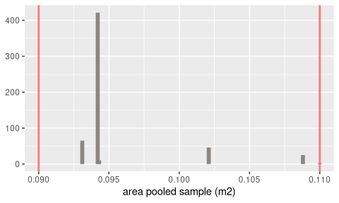

The pooled samples can be used to estimate biodiversity measures (see the next section for details). For instance, the species richness for each pool is given by:

```r
d <- oosterschelde %>%
    group_by(HABITAT, YEAR, POOLRUN, POOLID) %>%
    summarise(S = species_richness(taxon = TAXON, count = COUNT))
`summarise()` has grouped output by 'HABITAT', 'YEAR', 'POOLRUN'. You can override using the
`.groups` argument.
d
# A tibble: 569 × 5
# Groups:   HABITAT, YEAR, POOLRUN [60]
   HABITAT               YEAR  POOLRUN POOLID     S
   <chr>                 <chr>   <int>  <int> <int>
 1 Polyhaline-Intertidal 2010        1      1    24
 2 Polyhaline-Intertidal 2010        1      2    41
 3 Polyhaline-Intertidal 2010        1      3    21
 4 Polyhaline-Intertidal 2010        1      4    27
 5 Polyhaline-Intertidal 2010        1      5    31
 6 Polyhaline-Intertidal 2010        1      6    28
 7 Polyhaline-Intertidal 2010        1      7    28
 8 Polyhaline-Intertidal 2010        2      1    25
 9 Polyhaline-Intertidal 2010        2      2    25
10 Polyhaline-Intertidal 2010        2      3    29
# ℹ 559 more rows
```

The annual mean species richness for each habitat and year is given by:

```r
d <- d %>%
    group_by(HABITAT, YEAR) %>%
    summarise(S = mean(S))
`summarise()` has grouped output by 'HABITAT'. You can override using the `.groups` argument.
d
# A tibble: 6 × 3
# Groups:   HABITAT [2]
  HABITAT               YEAR      S
  <chr>                 <chr> <dbl>
1 Polyhaline-Intertidal 2010   28.6
2 Polyhaline-Intertidal 2011   34.8
3 Polyhaline-Intertidal 2012   32.3
4 Polyhaline-Subtidal   2010   35.6
5 Polyhaline-Subtidal   2011   46.7
6 Polyhaline-Subtidal   2012   46.9
```

## Biodiversity measures

Several biodiversity measures have been implemented in the `benthos`-package. In the sections below, we will demonstrate how to calculate these measures. To simplify things, all analysis will be performed on a single sampling unit:

```r
d <- oosterschelde %>%
    filter(HABITAT == "Polyhaline-Subtidal", YEAR == 2010, POOLRUN == 1, POOLID == 1) %>%
    select(TAXON, COUNT) %>%
    arrange(TAXON)
d
# A tibble: 41 × 2
   TAXON                  COUNT
   <chr>                  <dbl>
 1 Angulus tenuis             1
 2 Aphelochaeta marioni       1
 3 Aphelochaeta marioni      25
 4 Bathyporeia                2
 5 Capitella capitata         2
 6 Cossura longocirrata       1
 7 Echinocardium cordatum     1
 8 Ensis                      1
 9 Lanice conchilega          4
10 Magelona johnstoni         2
# ℹ 31 more rows
```

### Measures of species abundance

#### Total abundance

The total abundance is the total number of individuals in a sampling unit, and is computed by:

```r
d %>% total_abundance(count = COUNT)
[1] 131
```

#### Abundance

The abundance is the total number of individuals per taxon in a sampling unit. It can be computed by means of the `abundance`-function:

```r
d %>% abundance(taxon = TAXON, count = COUNT) %>% as.matrix
                       [,1]
Angulus tenuis            1
Aphelochaeta marioni     26
Bathyporeia               2
Capitella capitata        2
Cossura longocirrata      1
Echinocardium cordatum    1
Ensis                     1
Lanice conchilega         4
Magelona johnstoni        3
Magelona papillicornis    1
Malmgreniella lunulata    1
Mytilus edulis            1
Nemertea                  1
Nephtys                   8
Nephtys hombergii         1
Oligochaeta               8
Ophiura albida            6
Peringia ulvae            1
Poecilochaetus serpens    1
Pseudopolydora pulchra    1
Retusa obtusa             4
Scoloplos armiger        22
Spio martinensis          1
Spiophanes bombyx        17
Spisula                   1
Streblospio benedicti     1
Tellimya ferruginosa      1
Terebellidae              1
Urothoe poseidonis       12
```

### Measures of species richness

#### Species richness

Species richness $S$ is the number of different species in a (pooled) sample. It can be computed by means of

```r
d %>% species_richness(taxon = TAXON, count = COUNT)
[1] 29
```

#### Margalef’s index of diversity

Species richness $S$ is strongly dependent on sampling size. Margalef’s diversity index $D_\mathrm{M}$ takes sampling size into account. It is given by
$$D_\mathrm{M} = \frac{S-1}{\ln(N)}$$
where $N$ is the total abundance, *i.e*, the total number of individuals in the sampling unit. In case $N=1$, this index will be set to zero.

It can be computed for a specific sampling unit by:

```r
d %>% margalef(taxon = TAXON, count = COUNT)
[1] 5.743357
```

#### Rygg’s index of diversity

Species richness $S$ is strongly dependent on sampling size. Like Margalef’s diversity index $D_\mathrm{M}$, Rygg’s index of diversity takes sampling size into account (Rygg, 2006). It is given by
$$SN = \frac{\ln{S}}{\ln(\ln(N))}$$
where $N$ is the total abundance, *i.e*, the total number of individuals in the sampling unit.

It can be computed for a specific sampling unit by:

```r
d %>% rygg(taxon = TAXON, count = COUNT)
[1] 2.125603
```

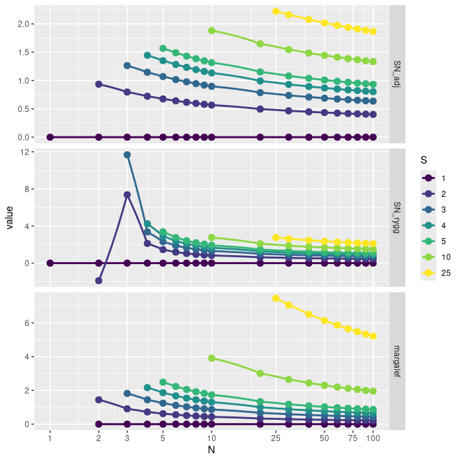

$$SNA = \frac{\ln{S}}{\ln(\ln(N+1)+1)}$$

The adjusted version of Rygg’s index can be computed by means of:

```r
d %>% rygg(taxon = TAXON, count = COUNT, adjusted = TRUE)
[1] 1.900244
```

#### Hurlbert’s $\mathrm{E}(S_n)$

Hurlbert (1971) gives the expected number of species in a sample of *n* individuals selected at random (without replacement) from a collection of *N* individuals and *S* species:

$$\mathrm{E}(S_n) = \sum_{i=1}^S \left[1 -
\frac{\binom{N-N_i}{n}}{\binom{N}{n}} \right]$$

Contrary to species richness, this measure is not dependent on the number of individuals. It can be computed for a specific sampling unit by:

```r
d %>% hurlbert(taxon = TAXON, count = COUNT, n = 100)
[1] 24.85011
```

$\mathrm{E}(S_n)$ can be computed for $n \in {1, 2, \dots, N}$, where $N$ is the total abundance. This has been done in the figure below.

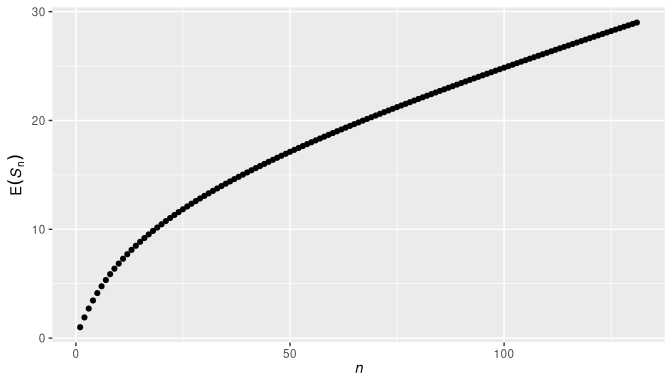

Note that $\mathrm{E}(S_n)$ can be computed for $n \leq N$. Extrapolation, *i.e.* $n > N$, is not possible.